# Minimal Example of Tutorial in Quarto with R and System Requirements

Author

Raniere Silva

This example illustrates the **required** metadata by [`andrew`](https://github.com/GESIS-Methods-Hub/andrew) for a tutorial written as a Quarto Document, an extension to Markdown (Gruber 2004).

Although footnotes are supported, the use of footnotes is discouraged[^1].

Math can be written using [LaTeX](https://www.latex-project.org/) and is render by [MathJax](https://www.mathjax.org/). Both inline, for example $x$, and standalone, for example
$$x = \sqrt{a^2 + b^2}\text{,}$$
is supported.

**Important**

To draw attention, wrap the text inside a callout blocks.

Cross reference of figures, tables, equations, … is also supported. For example, see Figure 1.

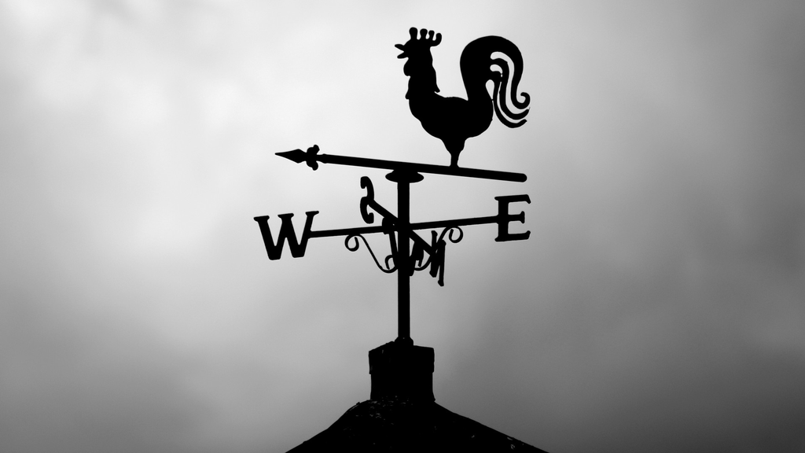

Figure 1: Photo of weathercock by Mat Brown. Available at https://www.pexels.com/photo/silhouette-of-wind-vane-552600/.

## Execution of R code

R code can be executed and the output can be included inline, for example `1 + 1` is equal to 2, and standalone, for example

```r
a <- 1
b <- 1

a + b
```

```
[1] 2
```

Annotation of code blocks is also supported. For example,

```r
(3 %/% 2) != (3 %% 2)
```

**1**

`%%` calculates the remainder on integer division.

## Creation of figure with R

```r
# We need a deterministic output here because we are using this for unit testing.

# data <- runif(10, min=0, max=10)
data <- c(
  9.0629027,
  5.3972500,
  0.4133466,
  0.3981549,
  6.8776325,
  7.6101721,
  8.9581236
)

plot(data, type='l')
```

[figure not shown]

## Dependencies

Packages that need to be installed for the reader should be listed in the `install.R` file. For example,

```r
install.packages("units")
```

R packages with system requirements, must have the system requirements installed using the `apt.txt`. For example,

```
libudunits2-dev
```

With the R package in the `install.R` file and the system requirements in the `apt.txt` file, is possible to execute

```r
library(units)
spd1 = set_units(1:5, m/s)

spd2 = set_units(1:5, km/h)

spd1 + spd2
```

```
Units: [m/s]
[1] 1.277778 2.555556 3.833333 5.111111 6.388889
```

## Binder

The link to Binder will launch [RStudio IDE](https://posit.co/products/open-source/rstudio-server/).

**Important**

Binder uses the information in `runtime.txt` to launch [RStudio IDE](https://posit.co/products/open-source/rstudio-server/).

## References

Gruber, John. 2004. “Markdown: Syntax.” *Daring Fireball*. https://daringfireball.net/projects/markdown/syntax.

## Footnotes

[^1]: Because of it makes navigation harder.